# R Notebook

Use `Rmarkdown` to do the following tasks(2). Please note that the presentation of the document and the range of `Rmarkdown` features/functions used are matter.

## 1. Describe a **real-world application** that uses topic modelling and explain how the topic model works. (4)

The online shopping recommendation system, such as JD recommendation system (A Chinese online shop), could use topic modelling to work. The key work is to calculate the similarity. All the works could be processed with three steps.

1. Calculating the distribution of topics for several items.
2. Calculating the similarity (Kullback-Leibler divergence could be used) among other items with the items you viewing based on the distribution of topics.
3. The item with higher similarity will get a higher chance for recommendation.

Once the system have your viewing history, then it could recommend the similar goods to you.

## 2. Download the Twitter dataset (rdmTweets-201306.RData) from the course website and do the following. (8)

```r
if(!require(twitteR))
    install.packages("twitteR")
if(!require(tm))
    install.packages("tm")
if(!require(wordcloud))
    install.packages("wordcloud")

library(tm)
library(wordcloud)
library(dplyr)
library(stringr)
library(tidyverse)

load('rdmTweets-201306.RData')
```

### a. Text cleaning: remove URLs, convert to lower case, and remove non-English letters or space.

```r
text_clean <- function(x) {
    text <- x$text
    # remove urls with header
    text <- gsub("https?://\\S+|www\\.\\S+", "", text)
    # remove urls without header
    text <- gsub("\\bwww[1-9a-zA-Z]*\\.\\S+", "", text)
    # convert to lower case and remove non-English letters and space
    text <- tolower(gsub("\\s+", " ", gsub("[^a-zA-Z ]", " ", text)))
    # remove the space located at the begining and the end
    trimws(text)
}
tweet_texts <- unlist(lapply(tweets, text_clean))
tweet_texts
```

```
##   [1] "examples on calling java code from r"
##   [2] "simulating map reduce in r for big data analysis using flights data via rbloggers"
##   [3] "job opportunity senior analyst big data at wesfarmers industrial amp safety sydney area australia jobs"
##   [4] "clavin an open source software package for document geotagging and geoparsing"
##   [5] "an online book on natural language processing with python"
##   [6] "tips for r programming provided on biostat wiki"
##   [7] "introduction to r for data mining a one hour video by revolution analytics"
##   [8] "the geonames geographical database geocode for countries cities suburbs places and postcodes"
##   [9] "result of kdnuggets annual software poll on software used in the past months for real projects via kdnuggets"
##  [10] "big geo data visualisations"
##  [11] "mapping the gdelt data in r"
##  [12] "airport airline and route data containing airports airlines and routes spanning the globe"
##  [13] "how to map connections with great circles"
##  [14] "gdelt global data on events location and tone containing over million geolocated events for to present"
##  [15] "nd cfp ausdm industry track submission due july"
```

[output cut: 305 more lines]

### b. Count the frequency of words “data” and “mining”.

*method 1: manually count the word ‘data’ and ‘mining’*

```r
freq.words <- data.frame(
  "data" = unlist(lapply(tweet_texts, function(x){
      words <- unlist(strsplit(x, "\\s+"))
      sum(words == "data")
    })) ,
  "mining" = unlist(lapply(tweet_texts, function(x){
      words <- unlist(strsplit(x, "\\s+"))
      sum(words == "mining")
    }))
)

freq <- freq.words %>% summarize(across(everything(), sum, na.rm=TRUE))
freq
```

| data | mining |
| --- | --- |
| 151 | 90 |

*method 2: count word using Corpus function*

```r
# concatenate all string into one
text_data <- paste(tweet_texts, collapse=" ")

# Create a corpus and perform text cleaning
text_corpus <- Corpus(VectorSource(text_data))
dtm <- DocumentTermMatrix(text_corpus)
dtm_matrix <- as.matrix(dtm)

freq <- gather(as.data.frame(dtm_matrix), key="col", value="c") %>%
  filter(col %in% c("data", "mining"))
freq
```

| col | c |
| --- | --- |
| data | 151 |
| mining | 90 |

### c. Plot the word cloud.

1. Merge all sentences.
2. Remove meaningless words.
3. Calculating word frequency.
4. Plot word cloud.

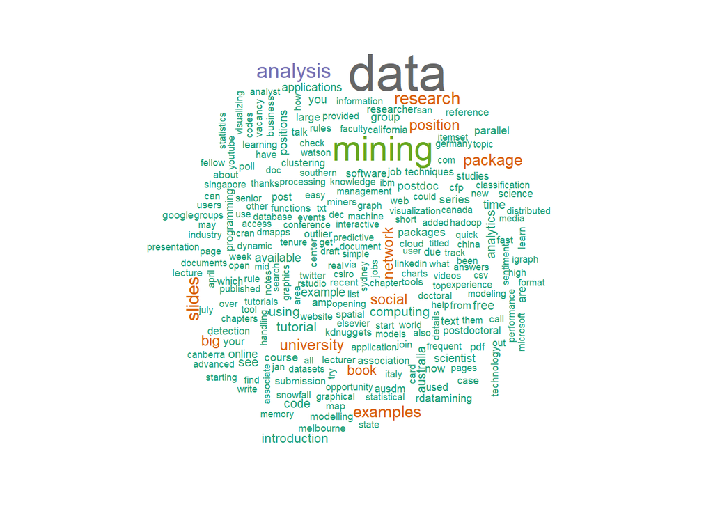

```r
# concatenate all string into one
text_data <- paste(tweet_texts, collapse=" ")

# Create a corpus and perform text cleaning
text_corpus <- Corpus(VectorSource(text_data))

# Remove the meaningless words
custom_stopwords <- c("the", "a", "an", "in", "on", "of", "to", "for", "with", "by", "and")
text_corpus <- tm_map(text_corpus, removeWords, custom_stopwords)

#text_corpus <- tm_map(text_corpus, content_transformer(tolower))
text_corpus <- tm_map(text_corpus, removePunctuation)

# Create a term-document matrix and calculate word frequencies
tdm <- TermDocumentMatrix(text_corpus)
word_freq <- rowSums(as.matrix(tdm))

# Create the word cloud
wordcloud(names(word_freq),
          freq = word_freq,
          scale = c(3, 0.5),
          min.freq = 3,
          colors = brewer.pal(8, "Dark2")
)
```

### d. Use a **topic modelling** algorithm to fit the Twitter data to 8 topics. Find the top 6 frequent terms (words) in each topic.

```r
if(!require(topicmodels))
    install.packages("topicmodels")
library("topicmodels")
```

```r
dtm <- DocumentTermMatrix(text_corpus)
# Specify the number of topics (k)
k <- 8

# Fit the LDA model
lda_model <- LDA(dtm,
                 k = k,
                 method = "Gibbs",
                 control = list(seed = 9999,
                                burnin = 1000,
                                thin = 100,
                                iter = 1000)
                 )

# Get 6 top frequency words with each topic
top_words <- terms(lda_model, 6)

lda_model
```

```
## A LDA_Gibbs topic model with 8 topics.
```

```r
top_words
```

```
##      Topic 1       Topic 2       Topic 3        Topic 4        Topic 5
## [1,] "programming" "examples"    "free"         "introduction" "data"
## [2,] "studies"     "online"      "text"         "slides"       "mining"
## [3,] "lecture"     "your"        "group"        "see"          "analysis"
## [4,] "see"         "ausdm"       "modelling"    "available"    "research"
## [5,] "opening"     "parallel"    "postdoc"      "from"         "package"
## [6,] "chapters"    "rdatamining" "postdoctoral" "researcher"   "university"
##      Topic 6    Topic 7     Topic 8
## [1,] "software" "example"   "applications"
## [2,] "due"      "reference" "codes"
## [3,] "map"      "canada"    "used"
## [4,] "via"      "center"    "access"
## [5,] "amp"      "cloud"     "business"
## [6,] "have"     "course"    "fast"
```

## 3. Provide a **real-world example** of a system or an application that utilises stream-data. In your example, explain the challenges faced by algorithms in analysing stream data and suggest some ideas to address those challenges (6)

**A real example of stream data application**

StockSight is an application that has been used for many organization. It uses the dataset from Twitter and news headlines data for stocks to analysis the sentiment of the author. Normally, Twitter and other news platforms owns a huge amount of data; more even, the data will be posted rapidly, especially on Twitter; some people also will add some slang, emojis, etc. that will make more challenging for analyzing; Lots of unrelated data exist, etc. All the problems are the challenges for implementation. The items listed below are some of my ideas for dealing with all the challenges.

1. Using stream sampling algorithm to deal with huge amount of data and rapid posting data.
2. Using NLP techniques to deal with the text, such as slang, emojis, etc.
3. Using classification method to deal with unrelated data.

**References**

https://github.com/shirosaidev/stocksight

## 4. Create a **data stream** of two dimensions data points. The data points will follow Gaussian distribution with 5% noise and belong to 4 clusters. Compare the performance of the following clustering methods in terms of precision, recall, and F1. (6)

```r
if(!require(stream))
  install.packages("stream")
library(stream)
```

```r
stream <- DSD_Gaussians(k = 4, d = 2, noise = .05, p = c(0.9, .5, .3, .1))
stream
```

```
## Gaussian Mixture (d = 2, k = 4)
## Class: DSD_Gaussians, DSD_R, DSD
```

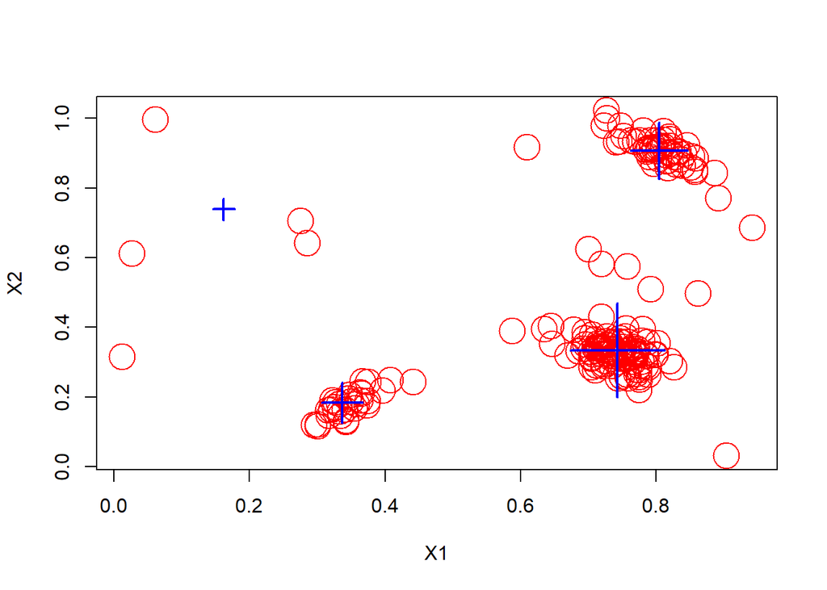

```r
Reservoir_Kmeans = DSC_TwoStage(
  micro = DSC_Sample(k = 200),
  macro = DSC_Kmeans(k = 4)
)
update(Reservoir_Kmeans, stream, n=500)
plot(Reservoir_Kmeans)
```

```r
evaluate_static(Reservoir_Kmeans,
                stream,
                measure =c("f1", "precision", "recall"),
                n =100
)
```

```
## Evaluation results for macro-clusters.
## Points were assigned to micro-clusters.
##
##        F1 precision    recall
## 0.9453104 0.8976417 0.9983259
## attr(,"type")
## [1] "macro"
## attr(,"assign")
## [1] "micro"
```

### **b.** Use Windowing method to get 200 data points from 500 data points of the stream. Use K-means to cluster the points in the window into 5 groups, and use 100 points from the stream to evaluate the performance of K-means.

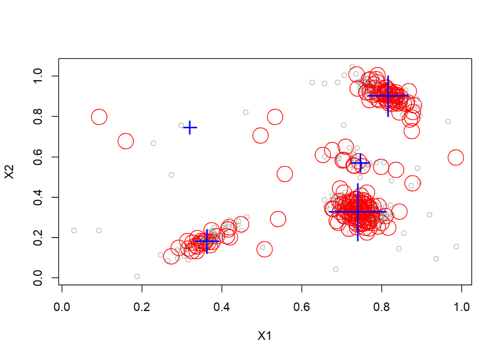

```r
Window_Kmeans = DSC_TwoStage(
  micro = DSC_Window(horizon = 200),
  macro = DSC_Kmeans(k = 5)
)
update(Window_Kmeans, stream, n=500)
#Window_Kmeans

plot(Window_Kmeans, stream)
```

```r
evaluate_static(
  Window_Kmeans,
  stream,
  measure = c("f1","precision","recall"),
  n =100
)
```

```
## Evaluation results for macro-clusters.
## Points were assigned to micro-clusters.
##
##        F1 precision    recall
## 0.9876278 0.9781566 0.9972841
## attr(,"type")
## [1] "macro"
## attr(,"assign")
## [1] "micro"
```

### **c.** Apply the D-Stream clustering method to 500 points from the stream with `gridsize=0.1`, and use 100 points from the stream to evaluate the performance of D-stream.

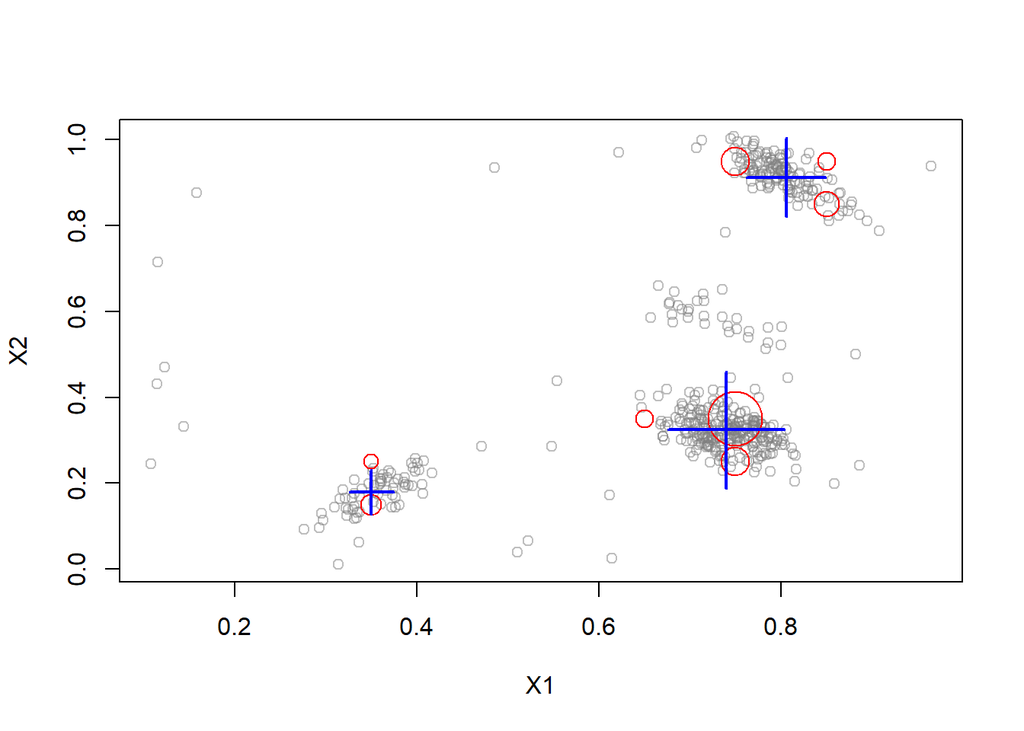

```r
dstream <- DSC_DStream(gridsize = .1, Cm = 1.2)
update(dstream, stream, n = 500)
plot(dstream, stream)
```

```r
evaluate_static(
  dstream,
  stream,
  measure = c("f1","precision","recall"),
  n =100
)
```

```
## Evaluation results for micro-clusters.
## Points were assigned to micro-clusters.
##
##        F1 precision    recall
## 0.5807339 0.8462567 0.4420391
## attr(,"type")
## [1] "micro"
## attr(,"assign")
## [1] "micro"
```

### Performance comparison

```r
reservoir <- evaluate_static(Reservoir_Kmeans,
                stream,
                measure =c("f1", "precision", "recall"),
                n =100
)

window <- evaluate_static(
  Window_Kmeans,
  stream,
  measure = c("f1","precision","recall"),
  n =100
)

dstream_p <- evaluate_static(
  dstream,
  stream,
  measure = c("f1","precision","recall"),
  n =100
)



performance <- rbind(t(reservoir[1:3]), t(window[1:3]))
performance <- rbind(performance, t(dstream_p[1:3]))

rownames(performance) <- c('reservoir', 'window', 'dstream')
performance
```

```
##                  F1 precision    recall
## reservoir 0.8908607 0.8066417 0.9947160
## window    0.9671362 0.9438717 0.9915764
## dstream   0.4672239 0.7855030 0.3324984
```

## 5. explain a **real-world application of geographical information system**. (4)

QGIS (Quantum GIS) is a powerful and open-source Geographical Information System (GIS) software that provides a comprehensive set of tools for managing, analyzing, and visualizing geographic and spatial data.

It is widely used for a variety of applications, from mapping and cartography to spatial analysis and data management.

Qgis allows users to import and manage kinds of data, and also provides a wide range of geospatial analysis tools for spatial queries, buffer analysis, spatial joins, proximity analysis, etc. Users can also create high-quality maps with symbols, labels and styling options. Besides, Qgis is also high customizable that allow users to adapt it to their specific needs.

The most important is that the Qgis is also an open source and community-driven software. It is freely available for everyone. Another important point is that it’s a cross-platform that is available for multiple operating system.

*References*

[QGIS: An Introduction to an Open-Source Geographic Information System](https://extension.msstate.edu/publications/qgis-introduction-open-source-geographic-information-system)

[QGIS Github Repository](https://github.com/qgis/QGIS)

## 6. Use spatial data analysis packages in R do the following tasks. **(10)**

### **a.** **Draw a map** of Australia where each city is represented as a dot. Highlight cities with population more than one million people. Map should have only the borders at country and state levels.

```r
if(!require(terra))
  install.packages("terra")
library(terra)
```

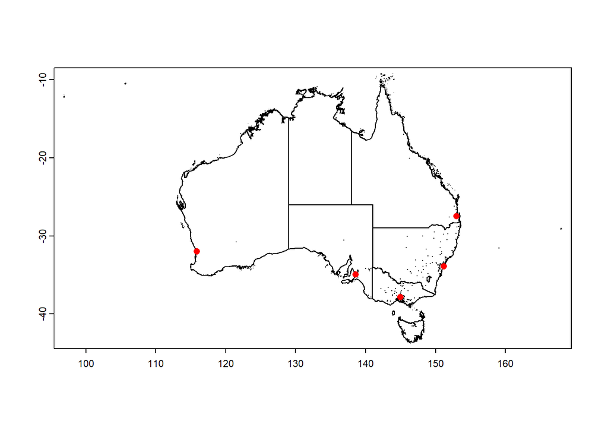

```r
filename <- paste0(getwd(),"/SA2_2021_AUST_SHP_GDA2020/SA2_2021_AUST_GDA2020.shp")
#basename(filename)
ausvec <- vect(filename)
# filter out all empty geometry
ausvec <- ausvec[!is.na(ausvec$AREASQKM21)]

# dissolve based states level
ausvecAgg <- aggregate(ausvec, by="STE_NAME21")

#load population data
auspop <- vect(paste0(getwd(),"/Australia_population.shp"))

#plot Australia with borders at country and state levels
plot(ausvecAgg)

# plot cities with less than 1 million population
plot(auspop[as.integer(auspop$population) < 1000000], add=TRUE, cex = 0.1)
# plot cities with greater than 1 million population, and highlight
plot(auspop[as.integer(auspop$population) >= 1000000], add=TRUE, col="red")
```

### **b.** Use the shapefile provided in the course website to draw a map of “South Australia”. Keep all borders in the map. Use a colour palette to highlight the statistical areas level 4 (SA4).

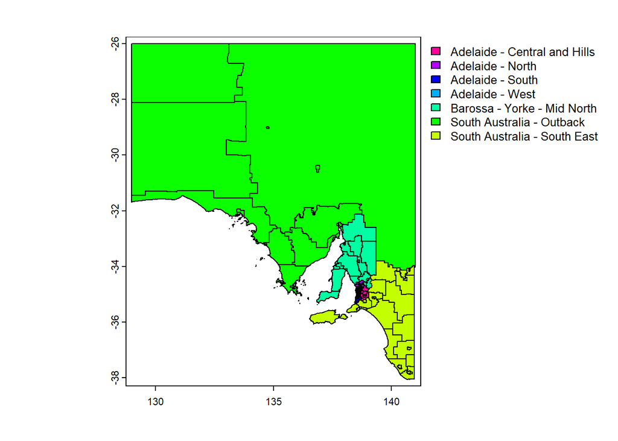

```r
# Plot South Australia

# select data of South Australia
sa <- ausvec[ausvec$STE_NAME21 == "South Australia"]

# dissolve based on SA4 level
sa4Agg <- aggregate(sa, by="SA4_NAME21")
plot(sa4Agg, c('SA4_NAME21'))
plot(sa, add=TRUE)
```

### **c.** **Create a spatial vector of “Greater Adelaide”**. Aggregate the polygons to draw a map that shows **only the borders** for statistical areas **level 3 (SA3)**.

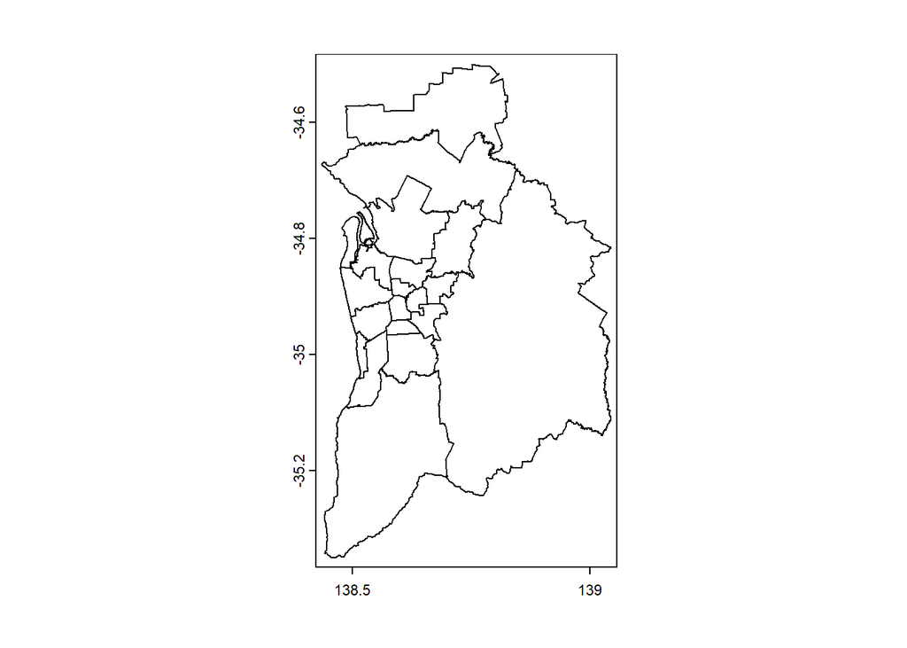

```r
greater_adelaide <- ausvec[ausvec$GCC_NAME21 == "Greater Adelaide"]
# dissolve based on SA4 level
greater_adelaide.sa3Agg <- aggregate(greater_adelaide, by="SA3_NAME21")

#plot only the level 3 border of Greater Adelaide
plot(greater_adelaide.sa3Agg)
```

### **d.** For this point you need to check the data in “crimeCounts.csv” available in the course website.

- Use the variable **“SA3_NAME21”** to obtain a spatial vector of “Salisbury”.

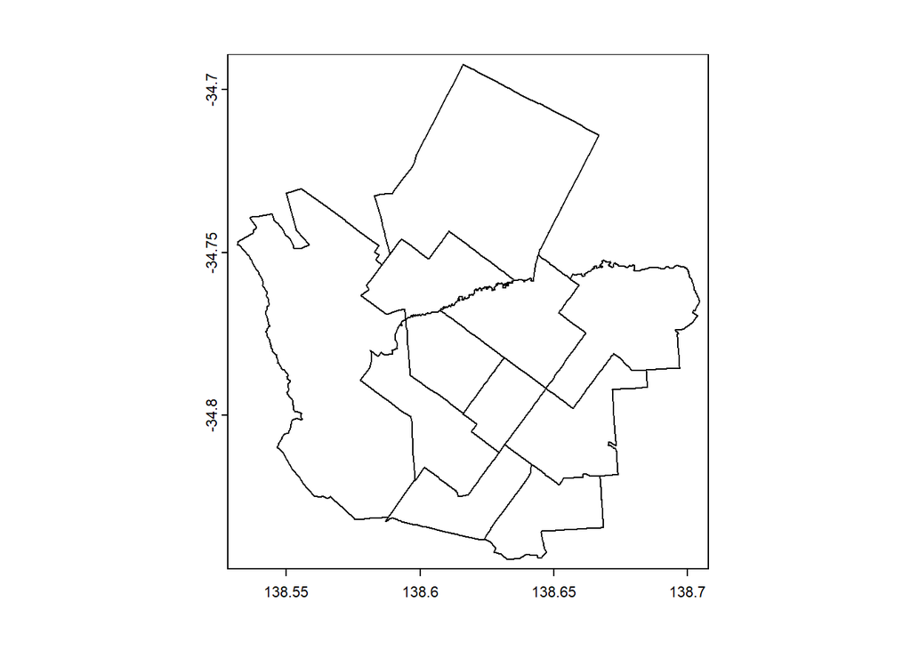

```r
salibury <- ausvec[ausvec$SA3_NAME21 == "Salisbury"]
plot(salibury)
```

- **create a new attribute** with the name `crimeCounts` containing the `offence count` (July 2022 – June 2023) for the suburbs in Salisbury spatial vector.

```r
# load crime data
crime_count <- read.csv('crimeCounts.csv')
# rename columns
names(crime_count) <- c('id', 'suburb', 'crimeCounts')
# convert to lower case for easy to compare
crime_count$lowerSub <- tolower(crime_count$suburb)

# create a suburb dataframe for merging
suburb.df <- data.frame(
  "lowerSub" = tolower(salibury$SA2_NAME21)
)
suburb.df <- left_join(suburb.df, crime_count, by="lowerSub")

#assign crimeCounts for the suburbs in Salisbury
salibury$crimeCounts <- suburb.df$crimeCounts

# show the count and suburbs
values(salibury) %>% select(SA2_NAME21, crimeCounts)
```

| SA2_NAME21 | crimeCounts |
| --- | --- |
| Dry Creek - North | NA |
| Ingle Farm | 642 |
| Para Hills | 434 |
| Parafield | 215 |
| Parafield Gardens | 874 |
| Paralowie | 1177 |
| Salisbury | 1636 |
| Salisbury East | 391 |
| Salisbury North | 792 |
| Mawson Lakes - Globe Derby Park | NA |

[output cut: 1 more lines]

- **Create a spatial raster** to display the crimeCounts in Salisbury. Select a colour palette so that high crimeCounts are represented in red colour.

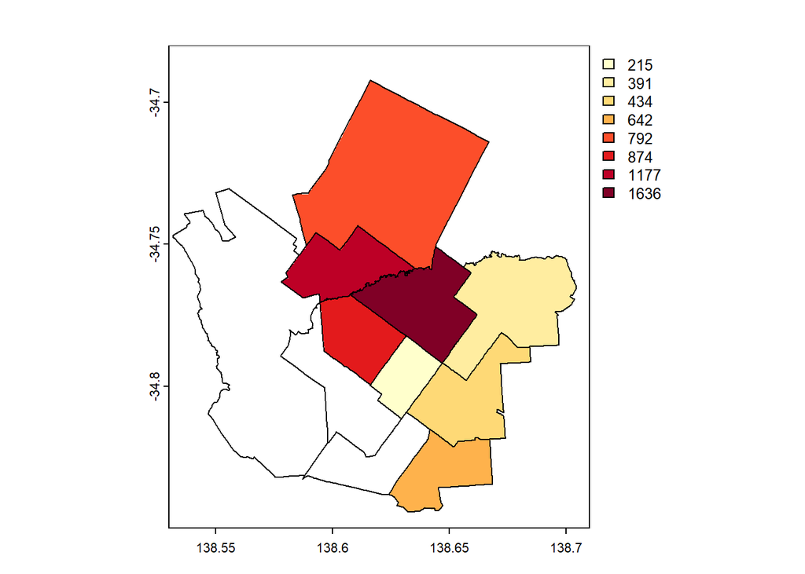

```r
#library(RColorBrewer)
#display.brewer.all()

salibury_raster <- rast(
  ncol=1000, nrow=1000,
  xmin=138.53, xmax=138.71,
  ymin=-34.85, ymax=-34.68
)

#Use a feature from the SpatVector as raster values
salibury_raster <- rasterize(salibury, salibury_raster, "crimeCounts")
terra::plot(salibury_raster, col=brewer.pal(9, "YlOrRd"))
terra::lines(salibury)
```

```r
#text(salibury, salibury$crimeCounts, inside=T, cex=0.6)
```

- Show **Salisbury** suburb names and borders in the map.

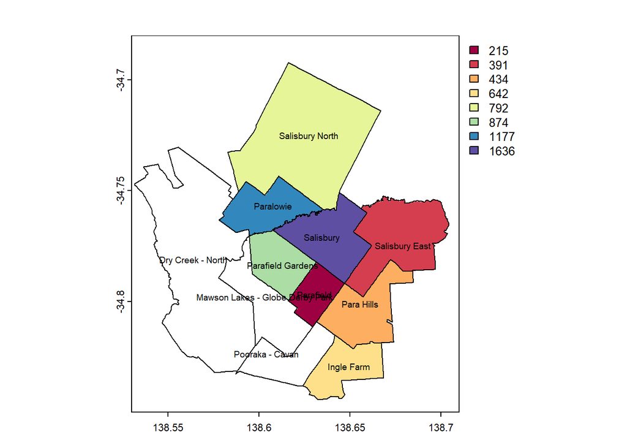

```r
salibury_raster <- rast(ncol=1000, nrow=1000, xmin=138.53, xmax=138.71, ymin=-34.85, ymax=-34.68)
#Use a feature from the SpatVector as raster values
salibury_raster <- rasterize(salibury, salibury_raster, "crimeCounts")
terra::plot(salibury_raster, col=brewer.pal(11, "Spectral"))
terra::lines(salibury)
text(salibury, salibury$SA2_NAME21, inside=T, cex=0.6)
```

### **e.** Create a **html page** with an interactive map containing the markers of your top 5 restaurants in Adelaide. Include in your report a screenshot of the interactive map. Upload the html as additional file in your submission.

```r
if(!require(leaflet))
  install.packages("leaflet")
if(!require(sf))
  install.packages("sf")
```

```r
library(sf)
library(leaflet)

# Create a leaflet map
leaflet() %>%
  addTiles() %>%  # Add a basemap
  addMarkers(lng = 138.60956081250663,lat = -34.92074609311045,popup = "Schnithouse Rundle St") %>%
  addMarkers(lng = 138.59883250622383,lat = -34.924407169226825,popup = "GEORGES") %>%
  addMarkers(lng = 138.5941120067306,lat = -34.92806706283753,popup = "Nu Thai Restaurant") %>%
  addMarkers(lng = 138.6006364073467, lat = -34.932289053377616, popup = "La Trattoria Restaurant & Pizza Bar") %>%
  addMarkers(lng = 138.61282628115364, lat = -34.93249827609448, popup = "Ballaboosta")
```

[interactive chart not shown]